# Laboratorio Modulo 1.

Raúl Correa Ocañas

2024-09-03

# Ejercicio 1.

*Encontrar la decomposición espectral de la siguiente matriz:* $\begin{bmatrix} 4.4 & 0.8 \\ 0.8 & 5.6\end{bmatrix}$*.*

Recordemos que una matriz $M$ tiene una decomposición espectral de la forma $M = Q\Lambda Q^{-1}$, tal que

$$Q = \begin{bmatrix} e_{1,1} & \cdots & e_{n,1} \\ \vdots &
\ddots & \vdots \\ e_{1,n} & \cdots & e_{n,n}\end{bmatrix},
\Lambda=\begin{bmatrix} \lambda_1 & \cdots & 0 \\ \vdots &
\ddots & \vdots \\ 0 & \cdots & \lambda_n\end{bmatrix}$$

Donde $Q$ es la matriz cuyas columnas son los eigenvectores de $M$, y $\Lambda$ es la matriz diagonal que contiene los eigenvalores correspondientes de $M$.

Una matriz $M$ es diagonalizable (es decir, tiene una descomposición espectral) si tiene un conjunto completo de eigenvectores linealmente independientes. En particular, si $M$ es una matriz simétrica, siempre es diagonalizable.

```r
M = matrix(c(4.4, 0.8, 0.8, 5.6), nrow = 2, byrow = TRUE)
eigen_M = eigen(M, symmetric = FALSE)
Q = eigen_M$vectors # Matriz de eigenvectores.
L = diag(eigen_M$values) # Matriz diagonal de eigenvalores.

Q %*% L %*% inv(Q)
```

```
##      [,1] [,2]
## [1,]  4.4  0.8
## [2,]  0.8  5.6
```

```r
Q
```

```
##            [,1]       [,2]
## [1,] -0.4472136 -0.8944272
## [2,] -0.8944272  0.4472136
```

```r
inv(Q)
```

```
##            [,1]       [,2]
## [1,] -0.4472136 -0.8944272
## [2,] -0.8944272  0.4472136
```

**Importante: La función `eigen()` muestra los eigenvectores unitarios.**

# Ejercicio 2.

Si $X$ se distribuye normalmente con una media $\mu = \begin{bmatrix} 2.5 \\ 4 \end{bmatrix}$ y una covarianza $\Sigma = \begin{bmatrix} 1.2 & 0 \\ 0 & 2.3 \end{bmatrix}$, calcular $P(X < x)$ donde $x = \begin{bmatrix} 2 \\ 3 \end{bmatrix}$.

```r
bound = c(2,3)
mu = c(2.5, 4)
sigma = matrix(c(1.2, 0, 0, 2.3), nrow = 2, byrow = TRUE)
p = pmnorm(x = bound, mean = mu, varcov = sigma)
cat("La probabilidad de X dado que sea acotada por x es:", round(p, 4))
```

```
## La probabilidad de X dado que sea acotada por x es: 0.0826
```

# Ejercicio 3.

Con los datos [datosX1X2X3.csv](https://experiencia21.tec.mx/courses/520587/files/190072137?wrap=1) del vector de variables aleatorio $X = (X_1, X_2, X_3)$ calcular las distancias de Mahalanobis y hallar las proporciones de datos por debajo de los percentiles de Chi-cuadrada corespondientes a 10, 20, 30, 40, 50, 60, 70, 80 y 90. Hacer una gráfica de Chi-2($1-\alpha$, gl = 3) vs la proporción hallada. ¿Se podría decir que X se distribuye normalmente?

Recordemos que la distancia de Mahalanobis está definida como:

$$d_M(x,Q)=\sqrt{(x-\mu)^T \Sigma^{-1}(x-\mu)}$$

$Q$ siendo una distribución normal multivariada en $\mathbb{R}^N$ con media $\mu = (\mu_1, \mu_2, \cdots,\mu_{N-1}, \mu_{N})$ y matriz de covarianzas $\Sigma$. En el caso de datos que siguen una distribución normal multivariada $X \sim \mathcal{N}(\mu, \Sigma)$, la distancia de Mahalanobis de una observación tiene una relación directa con la distribución Chi-cuadrada. Para una observación $x$ un conjunto de datos con $p$ variables, la distancia de Mahalanobis sigue una distribución Chi-cuadrada con $p$ grados de libertad.

```r
dataset = read.csv("data/datosX1X2X3.csv")
mu = colMeans(dataset)
sigma = cov(dataset)
stat_dist = mahalanobis(dataset, mu, sigma)

percentiles = qchisq(seq(0.1, 0.9, by = 0.1), df = 3)

proportions = sapply(percentiles, function(p) mean(stat_dist < p))

cbind(percentiles, proportions)
```

```
##       percentiles proportions
##  [1,]   0.5843744  0.03333333
##  [2,]   1.0051740  0.13333333
##  [3,]   1.4236522  0.30000000
##  [4,]   1.8691684  0.36666667
##  [5,]   2.3659739  0.46666667
##  [6,]   2.9461661  0.53333333
##  [7,]   3.6648708  0.73333333
##  [8,]   4.6416277  0.83333333
##  [9,]   6.2513886  0.93333333
```

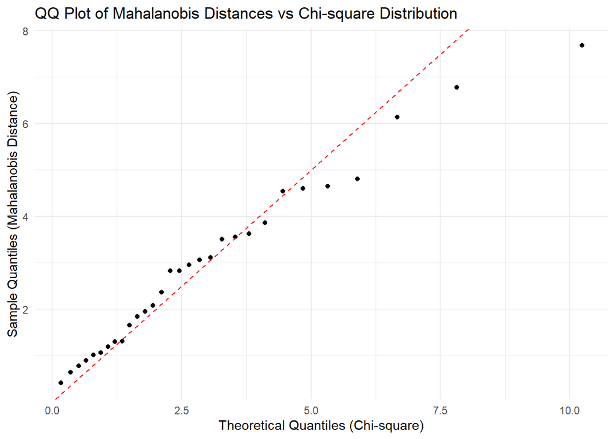

```r
qqplot_data <- data.frame(
  Theoretical = qchisq(ppoints(length(stat_dist)), df = 3),
  Sample = sort(stat_dist)
)

ggplot(qqplot_data, aes(sample = Sample, theoretical = Theoretical)) +
  geom_point(aes(x = Theoretical, y = Sample)) +
  geom_abline(slope = 1, intercept = 0, color = "red", linetype = "dashed") +
  labs(title = "QQ Plot of Mahalanobis Distances vs Chi-square Distribution",
       x = "Theoretical Quantiles (Chi-square)",
       y = "Sample Quantiles (Mahalanobis Distance)") +
  theme_minimal()
```

# Ejercicio 4.

A los datos numéricos del problema 3 plantee las hipótesis de la Prueba de normalidad.

$H_0 :=$ La distribución de las variables conjuntas es una normal multivariada.

$H_A :=$ La distribución de las variables conjuntas NO es una normal multivariada.

```r
mvn_mardia = mvn(dataset, mvnTest = "mardia")
mvn_hz = mvn(dataset, mvnTest = "hz")

p_mardia = mvn_mardia$multivariateNormality$`p value`
p_hz = mvn_hz$multivariateNormality$`p value`

# ¿Cuál es el valor p de correspondientes a los Test de sesgo y curtosis de la Prueba de normalidad multivariada de Mardia?
print(paste("P-Value Sesgo Mardia:", p_mardia[1]))
```

```
## [1] "P-Value Sesgo Mardia: 0.659972337630838"
```

```r
print(paste("P-Value Curtosis Mardia:", p_mardia[2]))
```

```
## [1] "P-Value Curtosis Mardia: 0.240490081413617"
```

```r
# ¿Cual es el valor p de la prueba de normalidad multivaridad de Henze-Zirkler's?
print(paste("P-Value HZ:", p_hz))
```

```
## [1] "P-Value HZ: 0.503368731490781"
```

A un alfa = 0.05, ¿qué se concluye?

Para todas las pruebas, no se tiene suficiente evidencia estadística para rechazar la hipótesis nula, por lo que se infiere que el sesgo y curtosis son correspondientes a una distribución normal multivariada. Respaldado por la prueba de normalidad de Henze-Zirkler’s, se confirma que efectivamente la distribución conjunta de los datos parece pertenecer a una distribución normal multivariada. Esto también se puede observar en la gráfica de “QQ Plot” Multivariada hecha en el ejercicio 3.

# Ejercicio 5.

El Departamento de Industria Primaria Pesca de Tasmania (Australia) hace un estudio sobre algunas características básicas del pez Olmo.

```r
dataset = read.csv("data/olmos.csv")
X = dataset[,c("Longitud", "Diametro", "Altura")]
head(dataset, 3)
```

```
##   Longitud Diametro Altura PesoTotal Pesodesvainado Pesovisceras Pesocorteza
## 1    0.530    0.420  0.135    0.6770         0.2565       0.1415        0.21
## 2    0.530    0.415  0.150    0.7775         0.2370       0.1415        0.33
## 3    0.545    0.425  0.125    0.7680         0.2940       0.1495        0.26
```

Realice un análisis de normalidad de las variables continuas para identificar variables normales:

1. Realice la prueba de normalidad de Mardia y la prueba de Anderson Darling con las variables $X1, X2$ y $X3$ y de la conclusión a un nivel se significación de 0.05. Interprete coeficientes de sesgo y curtosis de Mardia resultantes. Indique qué variables resultaron leptocúrticas, platicúrticas y mesocúrticas.

```r
mvn_dataset = mvn(data = X, mvnTest = "mardia", univariateTest = "AD")

mvn_dataset
```

```
## $multivariateNormality
##              Test         Statistic            p value Result
## 1 Mardia Skewness  17.0312537859682 0.0736752675872285    YES
## 2 Mardia Kurtosis 0.848747898502705  0.396021587220212    YES
## 3             MVN              <NA>               <NA>    YES
##
## $univariateNormality
##               Test  Variable Statistic   p value Normality
## 1 Anderson-Darling Longitud     0.6693    0.0725    YES
## 2 Anderson-Darling Diametro     0.6223    0.0955    YES
## 3 Anderson-Darling  Altura      0.2248    0.8041    YES
##
## $Descriptives
##           n      Mean    Std.Dev Median   Min   Max    25th    75th      Skew
## Longitud 30 0.5416667 0.06695770 0.5375 0.440 0.705 0.50125 0.56500 0.6684604
## Diametro 30 0.4265000 0.05841513 0.4225 0.335 0.560 0.39250 0.44375 0.6664298
## Altura   30 0.1420000 0.02558286 0.1400 0.100 0.200 0.12500 0.15875 0.2730008
##             Kurtosis
## Longitud  0.07671835
## Diametro -0.04598915
## Altura   -0.58397509
```

2. Elabore la gráfica de contorno de la normal multivariada obtenida anteriormente.

```r
# mvn(X, mvnTest = "mardia", multivariatePlot = "contour")
```

3. Con el vector de medias y la matriz de covarianza de la normal multivariada en en el inciso A, calcule la probabilidad de que $P(X ≤ (0.25, 0.25, 0.25) )$

```r
# Vector de medias y matriz de covarianza
mu = colMeans(X)
sigma = cov(X)
bound = c(0.25, 0.25, 0.25)

# Calcular la probabilidad utilizando la distribución normal multivariada
p_value = pmnorm(x = bound, mean = mu, varcov = sigma)
p_value
```

```
## [1] 6.623513e-06
```

4. Con el total de datos Olmos.csv calcula la distancia de Mahalanobis de cada observación al centroide (vector de medias) con respecto a la matriz de covarianzas. ¿Qué observación está más alejada, según la distancia de Mahalanobis, del centroide? ¿Qué observación está más cercana?

```r
# Distancia de Mahalanobis
mahalanobis_distances <- mahalanobis(X, center = mu, cov = sigma)

# Identificar la observación más alejada y la más cercana al centroide
max_distance_index <- which.max(mahalanobis_distances)
min_distance_index <- which.min(mahalanobis_distances)

max_distance_index
```

```
## [1] 17
```

```r
min_distance_index
```

```
## [1] 1
```

5. Aplica un análisis de componentes principales a los datos y con base en al menos tres criterios (por ejemplo, porcentaje de variación acumulada, gráfica de Scree y los valores de las cargas ) determinar cuántos componentes son suficientes para explicar razonablemente la mayoría de la variación.

```r
# Análisis de componentes principales
pca <- prcomp(dataset, scale. = TRUE)

# Porcentaje de variación acumulada
summary(pca)
```

```
## Importance of components:
##                           PC1     PC2     PC3     PC4     PC5     PC6     PC7
## Standard deviation     2.5274 0.53058 0.44469 0.28935 0.16163 0.13661 0.06806
## Proportion of Variance 0.9125 0.04022 0.02825 0.01196 0.00373 0.00267 0.00066
## Cumulative Proportion  0.9125 0.95273 0.98098 0.99294 0.99667 0.99934 1.00000
```

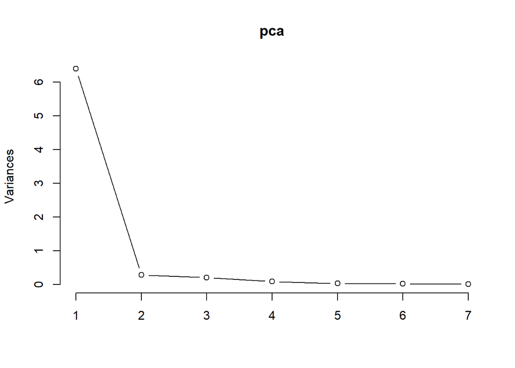

```r
# Gráfica Scree
screeplot(pca, type = "lines")
```

```r
# Valores de las cargas
pca$rotation
```

```
##                      PC1         PC2         PC3         PC4        PC5
## Longitud       0.3829206  0.01984410 -0.11178144 -0.82798216 -0.2777313
## Diametro       0.3895735 -0.01072829 -0.23266157 -0.19008711  0.6094553
## Altura         0.3571618  0.65634059  0.55239439  0.08997344  0.2658877
## PesoTotal      0.3913471 -0.14929602 -0.20861352  0.19596466 -0.0575013
## Pesodesvainado 0.3762967 -0.53901550  0.01823927  0.25053286  0.3175768
## Pesovisceras   0.3752590 -0.32334612  0.55274938  0.10746252 -0.4720819
## Pesocorteza    0.3721137  0.38900954 -0.52806230  0.39686290 -0.3920595
##                        PC6         PC7
## Longitud       -0.27298918 -0.05719002
## Diametro        0.61556971 -0.08655058
## Altura         -0.23308811  0.05823544
## PesoTotal      -0.09146657  0.85496423
## Pesodesvainado -0.52753646 -0.35442067
## Pesovisceras    0.45211736 -0.10137310
## Pesocorteza     0.03390893 -0.34495301
```

6. Escribir las combinaciones lineales de los Componentes principales en función de las variables y cargas obtenidas de los componentes principales resultantes.

```r
pca$rotation[,c(1,2)]
```

```
##                      PC1         PC2
## Longitud       0.3829206  0.01984410
## Diametro       0.3895735 -0.01072829
## Altura         0.3571618  0.65634059
## PesoTotal      0.3913471 -0.14929602
## Pesodesvainado 0.3762967 -0.53901550
## Pesovisceras   0.3752590 -0.32334612
## Pesocorteza    0.3721137  0.38900954
```

7. Utilizando los dos primeros componentes hacer una gráfica de dispersión de las puntuaciones. Comentar el gráfico en función de la variabilidad.

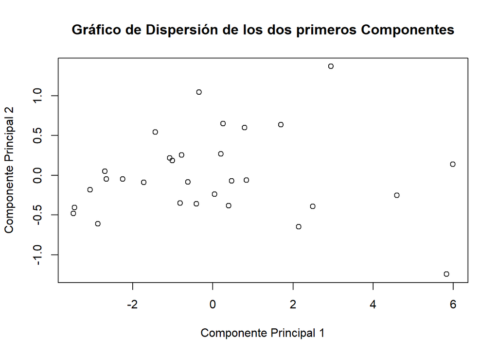

```r
# Obtener puntuaciones de los dos primeros componentes
scores <- pca$x[, 1:2]

# Gráfico de dispersión
plot(scores, xlab = "Componente Principal 1", ylab = "Componente Principal 2", main = "Gráfico de Dispersión de los dos primeros Componentes")
```

8. Hacer un gráfico vectorial de las variables e interpretar sus relaciones.

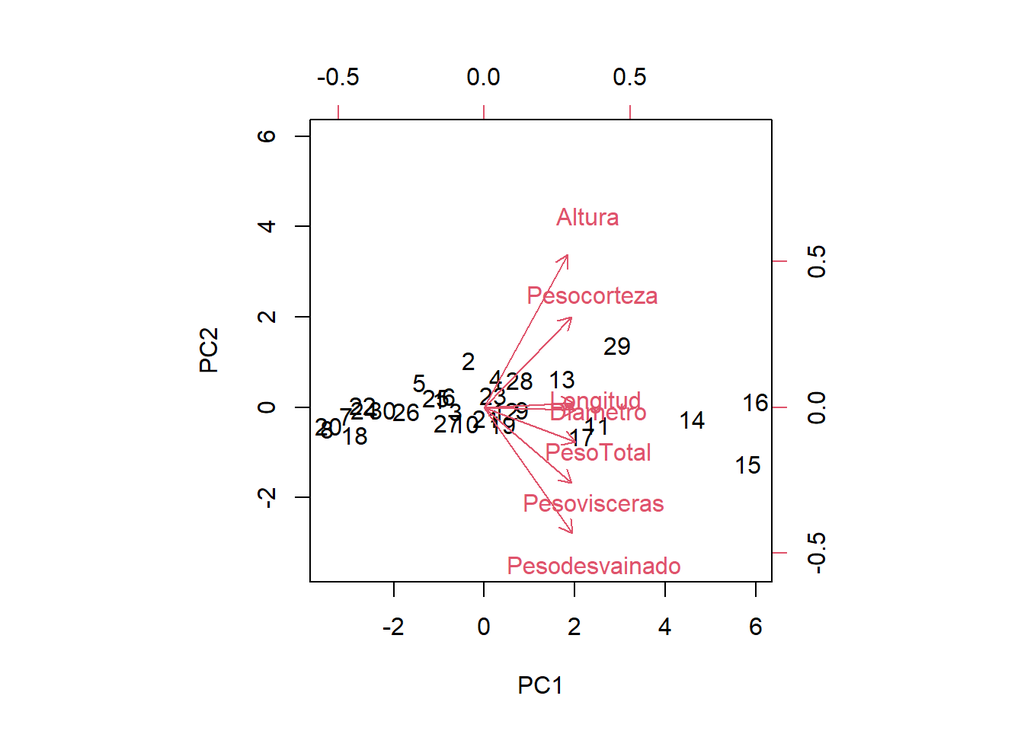

```r
# Gráfico biplot
biplot(pca, scale = 0)
```

# Ejercicio 6.

Con los mismos datos y contexto del problema anterior, realice un análisis factorial:

- Justifique por qué es adecuado el uso del Análisis factorial (hacer la prueba de esfericidad de Bartlett y KMO).

```r
# Matriz de correlación
corr.test(dataset)
```

```
## Call:corr.test(x = dataset)
## Correlation matrix
##                Longitud Diametro Altura PesoTotal Pesodesvainado Pesovisceras
## Longitud           1.00     0.96   0.86      0.95           0.90         0.90
## Diametro           0.96     1.00   0.86      0.98           0.93         0.91
## Altura             0.86     0.86   1.00      0.84           0.77         0.85
## PesoTotal          0.95     0.98   0.84      1.00           0.97         0.93
## Pesodesvainado     0.90     0.93   0.77      0.97           1.00         0.95
## Pesovisceras       0.90     0.91   0.85      0.93           0.95         1.00
## Pesocorteza        0.90     0.94   0.86      0.94           0.84         0.81
##                Pesocorteza
## Longitud              0.90
## Diametro              0.94
## Altura                0.86
## PesoTotal             0.94
## Pesodesvainado        0.84
## Pesovisceras          0.81
## Pesocorteza           1.00
## Sample Size
## [1] 30
## Probability values (Entries above the diagonal are adjusted for multiple tests.)
##                Longitud Diametro Altura PesoTotal Pesodesvainado Pesovisceras
## Longitud              0        0      0         0              0            0
## Diametro              0        0      0         0              0            0
## Altura                0        0      0         0              0            0
## PesoTotal             0        0      0         0              0            0
## Pesodesvainado        0        0      0         0              0            0
## Pesovisceras          0        0      0         0              0            0
## Pesocorteza           0        0      0         0              0            0
##                Pesocorteza
## Longitud                 0
## Diametro                 0
## Altura                   0
## PesoTotal                0
## Pesodesvainado           0
## Pesovisceras             0
## Pesocorteza              0
##
##  To see confidence intervals of the correlations, print with the short=FALSE option
```

```r
# Prueba de esfericidad de Bartlett
check_sphericity_bartlett(dataset)
```

```
## # Test of Sphericity
##
## Bartlett's test of sphericity suggests that there is sufficient significant correlation in the data for factor analysis (Chisq(21) = 426.64, p < .001).
```

```r
# Medida de adecuación muestral de Kaiser-Meyer-Olkin (KMO)
KMO(cor(dataset))
```

```
## Kaiser-Meyer-Olkin factor adequacy
## Call: KMO(r = cor(dataset))
## Overall MSA =  0.84
## MSA for each item =
##       Longitud       Diametro         Altura      PesoTotal Pesodesvainado
##           0.92           0.93           0.82           0.78           0.83
##   Pesovisceras    Pesocorteza
##           0.83           0.76
```

- Justifique el número de factores principales que se utilizarán en el modelo.

```r
pca = prcomp(dataset)
# Eigenvalores
pca$sdev
```

```
## [1] 0.427139183 0.053734410 0.027774291 0.020152956 0.014667729 0.009313184
## [7] 0.007361492
```

```r
# Aportacion acumulada
cumsum(pca$sdev) / sum(pca$sdev)
```

```
## [1] 0.7625535 0.8584832 0.9080675 0.9440457 0.9702314 0.9868578 1.0000000
```

```r
# Combinaciones Lineales
pca$rotation
```

```
##                       PC1         PC2          PC3         PC4         PC5
## Longitud       0.14890586  0.07635415  0.468234796 -0.75503238 -0.18936524
## Diametro       0.13388178  0.07957222  0.137250190 -0.28098170 -0.18290039
## Altura         0.05072929  0.08235490  0.357662557  0.18274943 -0.19340250
## PesoTotal      0.86583167  0.13198558 -0.144383206 -0.01669354  0.44900012
## Pesodesvainado 0.34778797 -0.64252207 -0.319294494 -0.01535904 -0.59799027
## Pesovisceras   0.18441539 -0.35875918  0.714928360  0.45095235  0.07241479
## Pesocorteza    0.22956321  0.64968687 -0.008832536  0.33720238 -0.57345127
##                         PC6         PC7
## Longitud        0.382533847  0.02209150
## Diametro       -0.862871702 -0.31615736
## Altura         -0.258193127  0.85161971
## PesoTotal      -0.003157374  0.10089134
## Pesodesvainado  0.053929652  0.05935724
## Pesovisceras    0.070030767 -0.33563973
## Pesocorteza     0.186101870 -0.21896115
```

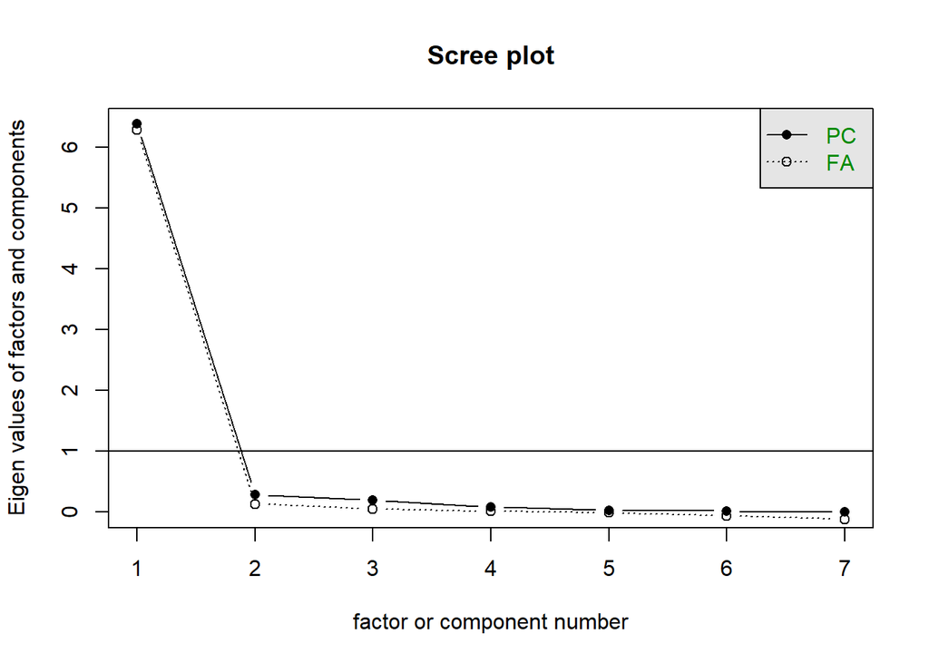

```r
cor_dataset = cor(dataset)
scree(cor_dataset)
```

- Identifique las comunalidades de los factores del modelo propuesto, y los errores: interprete si se necesita un nuevo factor.

```r
fm_mode = "mle" # minres

fa = fa(cor_dataset, nfactors = 2, rotate = "none", fm = fm_mode)
fa_varimax = fa(cor_dataset, nfactors = 2, rotate = "varimax", fm = fm_mode)
fa_oblimin = fa(cor_dataset, nfactors = 2, rotate = "oblimin", fm = fm_mode)
```

```r
data.frame(NONE = fa$communalities, VARIMAX = fa_varimax$communalities, OBLIMIN = fa_oblimin$communalities)
```

```
##                     NONE   VARIMAX   OBLIMIN
## Longitud       0.9082409 0.9082409 0.9082409
## Diametro       0.9663126 0.9663126 0.9663126
## Altura         0.7710551 0.7710551 0.7710551
## PesoTotal      0.9950000 0.9950000 0.9950000
## Pesodesvainado 0.9950000 0.9950000 0.9950000
## Pesovisceras   0.9049346 0.9049346 0.9049346
## Pesocorteza    0.9728227 0.9728227 0.9728227
```

```r
cbind(fa$residual, fa_varimax$residual, fa_oblimin$residual)
```

```
##                     Longitud      Diametro       Altura     PesoTotal
## Longitud        0.0917700579  0.0267929754  0.034291184 -0.0003790692
## Diametro        0.0267929754  0.0336875996  0.012658086 -0.0002211181
## Altura          0.0342911838  0.0126580860  0.228936457 -0.0049561387
## PesoTotal      -0.0003790692 -0.0002211181 -0.004956139  0.0043868585
## Pesodesvainado -0.0027295438 -0.0006517700 -0.003381513  0.0003974553
## Pesovisceras    0.0241239903  0.0030402730  0.099524340 -0.0002896105
## Pesocorteza    -0.0156089015 -0.0053188250 -0.001635717  0.0022259817
##                Pesodesvainado  Pesovisceras   Pesocorteza      Longitud
## Longitud        -0.0027295438  0.0241239903 -0.0156089015  0.0917700579
## Diametro        -0.0006517700  0.0030402730 -0.0053188250  0.0267929754
## Altura          -0.0033815130  0.0995243404 -0.0016357171  0.0342911838
## PesoTotal        0.0003974553 -0.0002896105  0.0022259817 -0.0003790692
## Pesodesvainado   0.0049208553 -0.0007850280  0.0001015824 -0.0027295438
## Pesovisceras    -0.0007850280  0.0950610619 -0.0143984937  0.0241239903
## Pesocorteza      0.0001015824 -0.0143984937  0.0271771040 -0.0156089015
##                     Diametro       Altura     PesoTotal Pesodesvainado
## Longitud        0.0267929754  0.034291184 -0.0003790692  -0.0027295438
## Diametro        0.0336875996  0.012658086 -0.0002211181  -0.0006517700
## Altura          0.0126580860  0.228936457 -0.0049561387  -0.0033815130
## PesoTotal      -0.0002211181 -0.004956139  0.0043868585   0.0003974553
## Pesodesvainado -0.0006517700 -0.003381513  0.0003974553   0.0049208553
## Pesovisceras    0.0030402730  0.099524340 -0.0002896105  -0.0007850280
## Pesocorteza    -0.0053188250 -0.001635717  0.0022259817   0.0001015824
##                 Pesovisceras   Pesocorteza      Longitud      Diametro
## Longitud        0.0241239903 -0.0156089015  0.0917700579  0.0267929754
## Diametro        0.0030402730 -0.0053188250  0.0267929754  0.0336875996
## Altura          0.0995243404 -0.0016357171  0.0342911838  0.0126580860
## PesoTotal      -0.0002896105  0.0022259817 -0.0003790692 -0.0002211181
## Pesodesvainado -0.0007850280  0.0001015824 -0.0027295438 -0.0006517700
## Pesovisceras    0.0950610619 -0.0143984937  0.0241239903  0.0030402730
## Pesocorteza    -0.0143984937  0.0271771040 -0.0156089015 -0.0053188250
##                      Altura     PesoTotal Pesodesvainado  Pesovisceras
## Longitud        0.034291184 -0.0003790692  -0.0027295438  0.0241239903
## Diametro        0.012658086 -0.0002211181  -0.0006517700  0.0030402730
## Altura          0.228936457 -0.0049561387  -0.0033815130  0.0995243404
## PesoTotal      -0.004956139  0.0043868585   0.0003974553 -0.0002896105
## Pesodesvainado -0.003381513  0.0003974553   0.0049208553 -0.0007850280
## Pesovisceras    0.099524340 -0.0002896105  -0.0007850280  0.0950610619
## Pesocorteza    -0.001635717  0.0022259817   0.0001015824 -0.0143984937
##                  Pesocorteza
## Longitud       -0.0156089015
## Diametro       -0.0053188250
## Altura         -0.0016357171
## PesoTotal       0.0022259817
## Pesodesvainado  0.0001015824
## Pesovisceras   -0.0143984937
## Pesocorteza     0.0271771040
```

```r
mr1 = data.frame(MR1_NONE = fa$loadings[,1], MR1_VARIMAX = fa_varimax$loadings[,1], MR1_OBLIMIN = fa_oblimin$loadings[,1])

mr2 = data.frame(MR2_NONE = fa$loadings[,2], MR2_VARIMAX = fa_varimax$loadings[,2], MR1_OBLIMIN = fa_oblimin$loadings[,2])

mr1
```

```
##                 MR1_NONE MR1_VARIMAX MR1_OBLIMIN
## Longitud       0.9424039   0.7098984   0.9526608
## Diametro       0.9728891   0.7284945   0.9828062
## Altura         0.8317595   0.7470324   0.8593335
## PesoTotal      0.9948378   0.6932993   0.9970416
## Pesodesvainado 0.9832828   0.4972108   0.9565545
## Pesovisceras   0.9442107   0.5125709   0.9239430
## Pesocorteza    0.9156153   0.8661371   0.9527012
```

```r
mr2
```

```
##                   MR2_NONE MR2_VARIMAX MR1_OBLIMIN
## Longitud        0.14179155   0.6358256  0.04270583
## Diametro        0.14070995   0.6600061  0.03844933
## Altura          0.28149539   0.4615258  0.19320551
## PesoTotal       0.07688238   0.7175996 -0.02732640
## Pesodesvainado -0.16802987   0.8647893 -0.26972122
## Pesovisceras   -0.11578011   0.8013801 -0.21367472
## Pesocorteza     0.36670360   0.4718362  0.26920819
```

```r
fa_oblimin
```

```
## Factor Analysis using method =  ml
## Call: fa(r = cor_dataset, nfactors = 2, rotate = "oblimin", fm = fm_mode)
## Standardized loadings (pattern matrix) based upon correlation matrix
##                 ML1   ML2   h2     u2 com
## Longitud       0.95  0.04 0.91 0.0918 1.0
## Diametro       0.98  0.04 0.97 0.0337 1.0
## Altura         0.86  0.19 0.77 0.2289 1.1
## PesoTotal      1.00 -0.03 1.00 0.0044 1.0
## Pesodesvainado 0.96 -0.27 1.00 0.0049 1.2
## Pesovisceras   0.92 -0.21 0.90 0.0951 1.1
## Pesocorteza    0.95  0.27 0.97 0.0272 1.2
##
##                        ML1  ML2
## SS loadings           6.28 0.23
## Proportion Var        0.90 0.03
## Cumulative Var        0.90 0.93
## Proportion Explained  0.96 0.04
## Cumulative Proportion 0.96 1.00
##
##  With factor correlations of
##       ML1   ML2
## ML1  1.00 -0.01
## ML2 -0.01  1.00
##
## Mean item complexity =  1.1
## Test of the hypothesis that 2 factors are sufficient.
##
## df null model =  21  with the objective function =  16.52
## df of  the model are 8  and the objective function was  1.36
##
## The root mean square of the residuals (RMSR) is  0.02
## The df corrected root mean square of the residuals is  0.04
##
## Fit based upon off diagonal values = 1
## Measures of factor score adequacy
##                                                    ML1  ML2
## Correlation of (regression) scores with factors   1.00 0.96
## Multiple R square of scores with factors          1.00 0.93
## Minimum correlation of possible factor scores     0.99 0.86
```

- Encuentre con ayuda de un gráfico de variables qué conviene más sin rotación o con rotación varimax. (se puede ayudar con la función fa de la librería psych y el gráfico de la función fa.diagram)

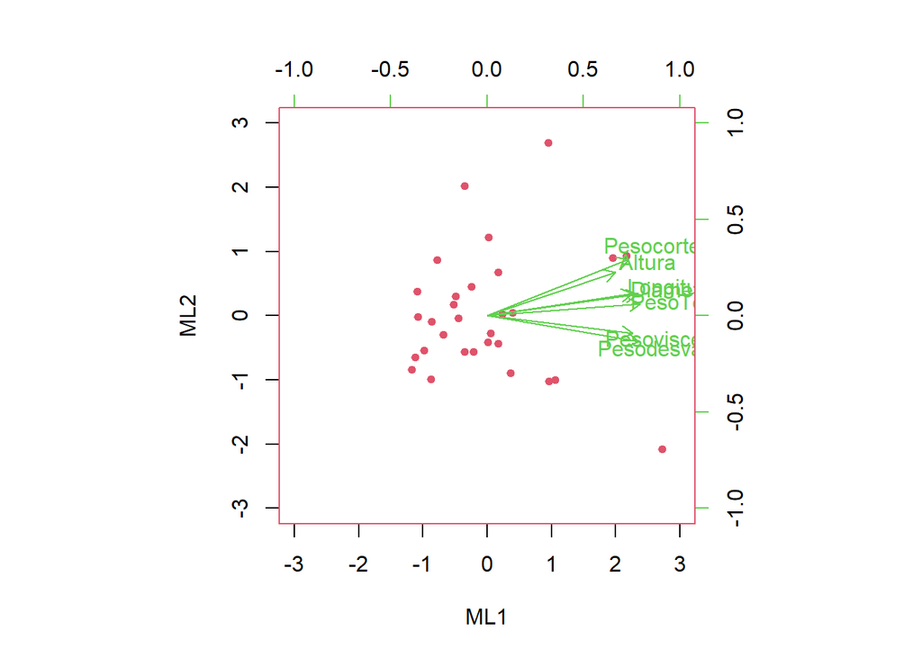

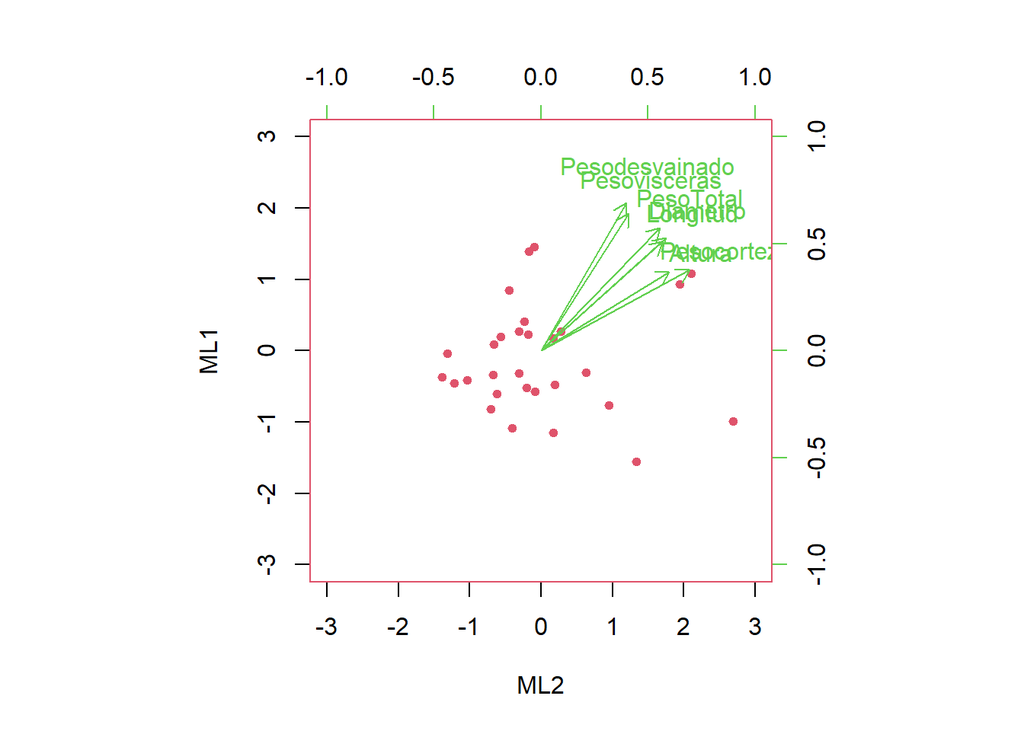

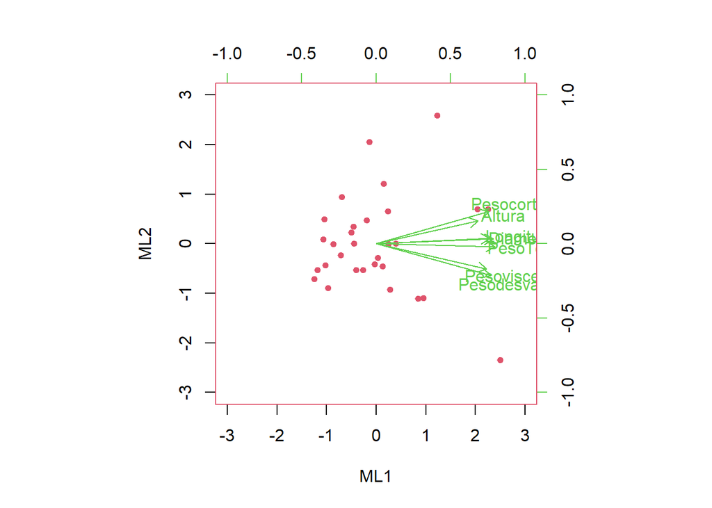

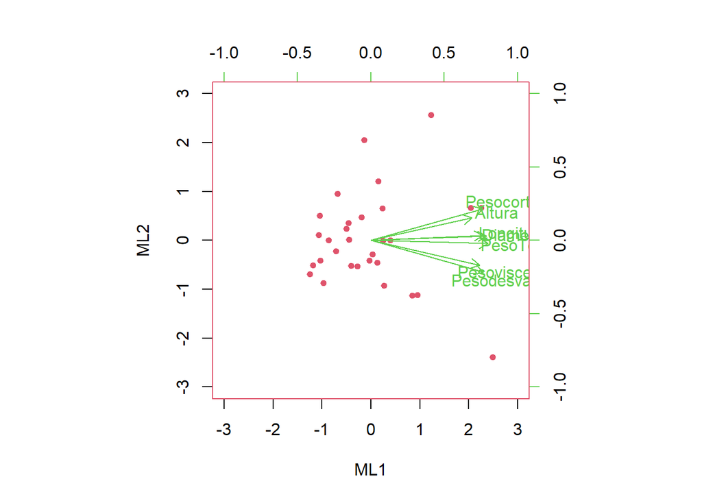

```r
rot = c("none", "varimax", "quartimax", "oblimin")
bi_mod = function(tipo){
biplot.psych(fa(dataset, nfactors = 2, fm=fm_mode, rotate = tipo), main = "",col=c(2,3,4),pch = c(21,18))  }
sapply(rot,bi_mod)
```

- ¿Tienen interpretación en el contexto del problema los factores encontrados?

# Ejercicio 7.

La base de datos *iris* en R almacena datos de las características de 3 especies de Lilis: Setosa, Versicolor y Virginica. Realiza un análisis Clouster para determinar qué tan bien están clasificadas las flores en su especie. Haz un análisis de la siguiente forma:

```r
data(iris)
head(iris,3)
```

```
##   Sepal.Length Sepal.Width Petal.Length Petal.Width Species
## 1          5.1         3.5          1.4         0.2  setosa
## 2          4.9         3.0          1.4         0.2  setosa
## 3          4.7         3.2          1.3         0.2  setosa
```

- Haz un leve análisis descriptivo para cada variable por especie: media, desviación estándar, diagramas de caja y bigote

```r
summary_stats <- aggregate(. ~ Species, data = iris, FUN = function(x) c(mean = mean(x), sd = sd(x)))

summary_stats
```

```
##      Species Sepal.Length.mean Sepal.Length.sd Sepal.Width.mean Sepal.Width.sd
## 1     setosa         5.0060000       0.3524897        3.4280000      0.3790644
## 2 versicolor         5.9360000       0.5161711        2.7700000      0.3137983
## 3  virginica         6.5880000       0.6358796        2.9740000      0.3224966
##   Petal.Length.mean Petal.Length.sd Petal.Width.mean Petal.Width.sd
## 1         1.4620000       0.1736640        0.2460000      0.1053856
## 2         4.2600000       0.4699110        1.3260000      0.1977527
## 3         5.5520000       0.5518947        2.0260000      0.2746501
```

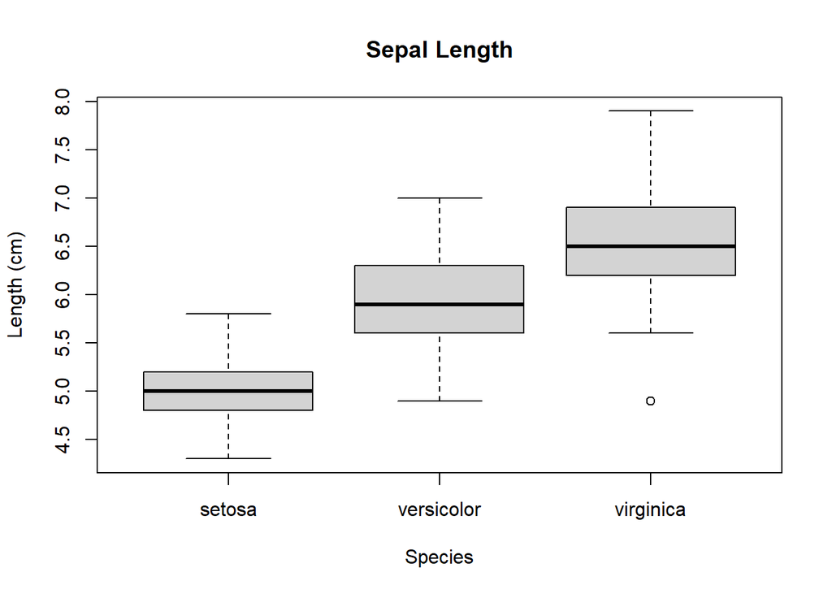

```r
# Diagramas de caja y bigote por variable y especie
boxplot(Sepal.Length ~ Species, data = iris, main = "Sepal Length", ylab = "Length (cm)")
```

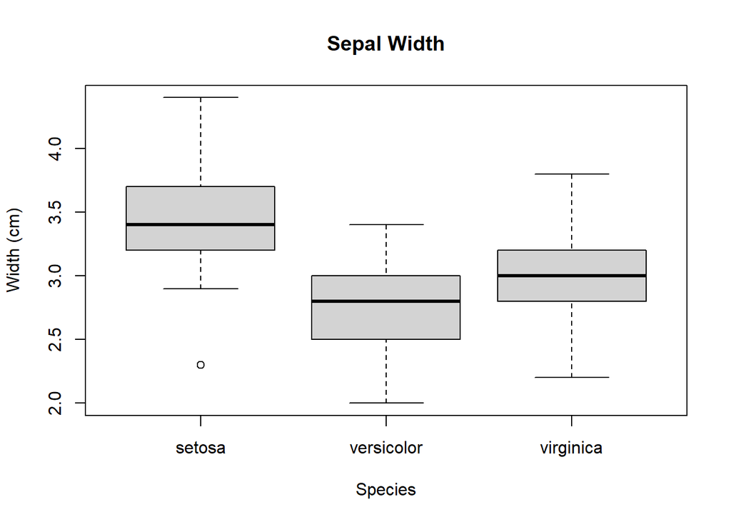

```r
boxplot(Sepal.Width ~ Species, data = iris, main = "Sepal Width", ylab = "Width (cm)")
```

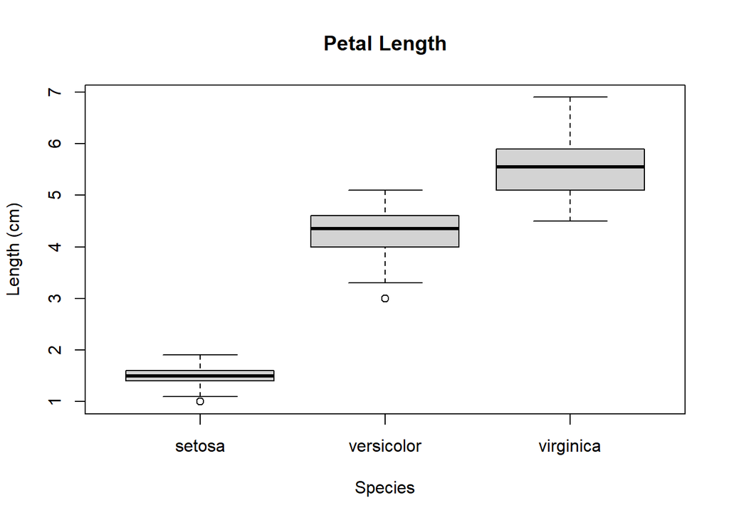

```r
boxplot(Petal.Length ~ Species, data = iris, main = "Petal Length", ylab = "Length (cm)")
```

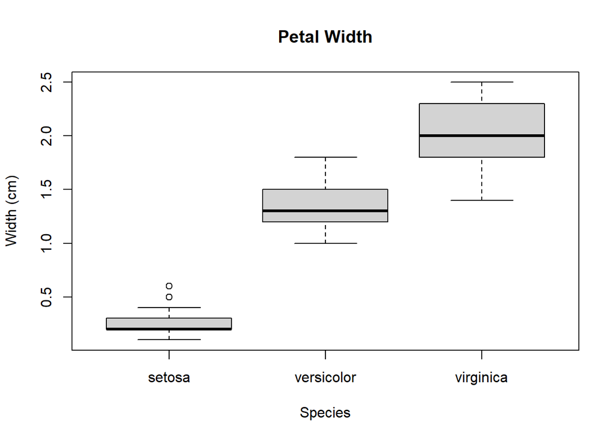

```r
boxplot(Petal.Width ~ Species, data = iris, main = "Petal Width", ylab = "Width (cm)")
```

- Realiza dos análisis clouster jerárquicos usando dos distintas distancias y métodos de aglomeración. Sigue los siguientes puntos para cada uno de ellos:
  - Realiza el dendograma y selecciona el número de grupos óptimo (k). Utiliza *rect.hclust*(jerarquico, *k* = número de grupos, *border*=“color”).
  - Visualiza las distancias entre los grupos que decidiste formar (te puede ayudar: jerarquico$height del comando hclust)
  - Identifica el grupo en que fue clasificada cada observación de la base de datos.
    - grupo = *cutree*(jerarquico, *k=*número de grupos)  
      Resultado = *cbind*(Iris, grupo)
  - Cuenta el número de observaciones mal clasificadas (puedes hacerlo con el comando *table*)
  - Calcula la media para cada grupo de clasificación por el método y comparalas con las obtenidas en el análisis descriptivo.
  - Interpreta el dendograma obtenido y concluye para los dos métodos. Indica cuál es mejor y por qué.

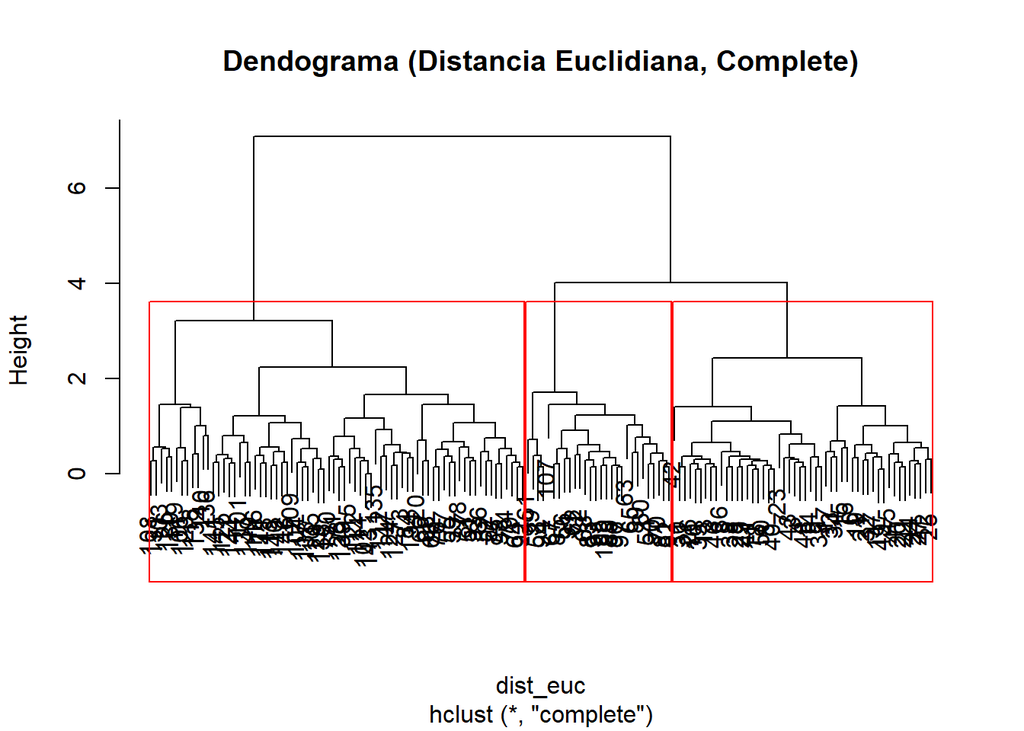

```r
groups = 3

# Cálculo de la matriz de distancias
dist_euc <- dist(iris[, -5], method = "euclidean")

# Clúster jerárquico usando el método "complete"
jerarquico1 <- hclust(dist_euc, method = "complete")

# Dendograma
plot(jerarquico1, main = "Dendograma (Distancia Euclidiana, Complete)")

# Seleccionar número óptimo de grupos y colorear el dendograma
rect.hclust(jerarquico1, k = groups, border = "red")
```

```r
# Asignación de grupos a cada observación
grupo1 <- cutree(jerarquico1, k = groups)

# Resultado: combinación de iris con el grupo asignado
resultado1 <- cbind(iris, Grupo = grupo1)

# Contar observaciones mal clasificadas
table(resultado1$Species, resultado1$Grupo)
```

```
##
##               1  2  3
##   setosa     50  0  0
##   versicolor  0 23 27
##   virginica   0 49  1
```

```r
# Calcular medias por grupo de clasificación
aggregate(. ~ Grupo, data = resultado1[, -5], FUN = mean)
```

```
##   Grupo Sepal.Length Sepal.Width Petal.Length Petal.Width
## 1     1     5.006000    3.428000     1.462000    0.246000
## 2     2     6.545833    2.963889     5.273611    1.850000
## 3     3     5.532143    2.635714     3.960714    1.228571
```

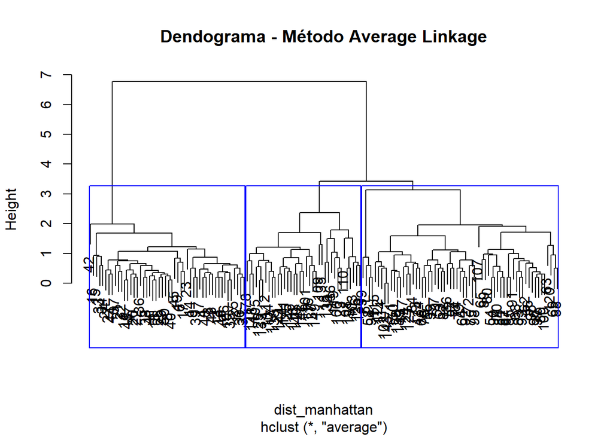

```r
groups = 3

# Clustering jerárquico usando la distancia Manhattan y el método de enlace promedio (average linkage)
dist_manhattan <- dist(iris[, -5], method = "manhattan")
jerarquico2 <- hclust(dist_manhattan, method = "average")

# Dendograma y selección del número óptimo de grupos
plot(jerarquico2, main = "Dendograma - Método Average Linkage")
rect.hclust(jerarquico2, k = groups, border = "blue")
```

```r
# Asignar las observaciones a los grupos
grupos2 <- cutree(jerarquico2, k = groups)
resultado2 <- cbind(iris, Grupo = grupos2)

# Contar las observaciones mal clasificadas
table(iris$Species, grupos2)
```

```
##             grupos2
##               1  2  3
##   setosa     50  0  0
##   versicolor  0 49  1
##   virginica   0 14 36
```

```r
aggregate(. ~ Grupo, data = resultado2[, -5], FUN = mean)
```

```
##   Grupo Sepal.Length Sepal.Width Petal.Length Petal.Width
## 1     1     5.006000    3.428000     1.462000    0.246000
## 2     2     5.917460    2.753968     4.401587    1.434921
## 3     3     6.848649    3.072973     5.764865    2.086486
```

- Hacer el gráfico de agromeración no-jerárquica con el método de k-medias para las especies de Iris.
  - Grafica el diagrama de aglomeración ideal
  - Cuenta el número de observaciones mal clasificadas
  - Calcula las medias para los grupos formados y comparalas con las obtenidas en el análisis descriptivo.
  - Interpreta el resultado obtenido y concluye

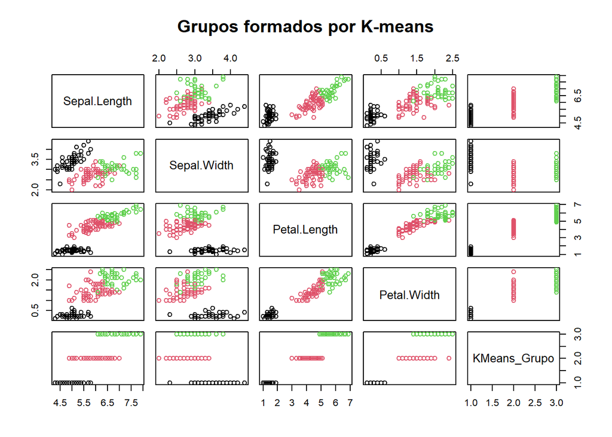

```r
# Análisis de K-means con k=3
set.seed(123)
kmeans_result <- kmeans(iris[, -5], centers = 3)

# Asignar las observaciones a los grupos formados por K-means
iris$KMeans_Grupo <- kmeans_result$cluster

# Gráfico de los grupos formados por K-means
pairs(iris[, -5], col = kmeans_result$cluster, main = "Grupos formados por K-means")
```

```r
# Contar las observaciones mal clasificadas
table(iris$Species, iris$KMeans_Grupo)
```

```
##
##               1  2  3
##   setosa     50  0  0
##   versicolor  0 48  2
##   virginica   0 14 36
```

- ¿Cuál de los dos métodos resultó mejor para la clasificación de acuerdo a la clasificacion de cada observación en las especies y en los grupos.